# Additional Summaries of the Simulation in Section 4.1 of ‘Efficient Estimation of the GP-P Regression Model’

Easton Huch and Candace Berrett

3/18/2022

## $\hat{\beta}_1$

Boxplots of the 1000 estimates of $\hat{\beta}_1$ (y-axis) for the thirteen fitted models (x-axis) and three sample sizes (denoted by color) when data were generated from the GP-P model for various values of $P$ and $\varphi$. The red horizontal line indicates the true data-generating value of $\beta_1$. Model-fitting approaches that fit the ``true" data-generating model have a darker background. The boxplots of estimates from the proposed maximum likelihood approach are slightly darkened.

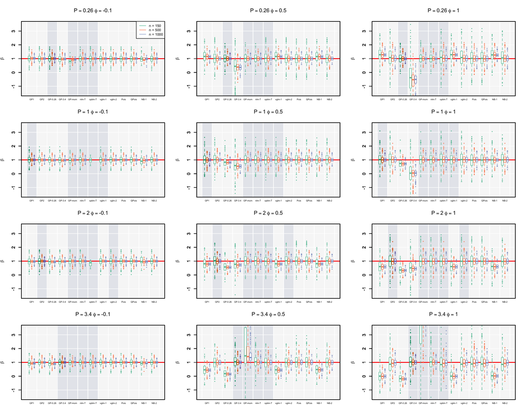

## 95% CI on $\beta_1$: WIDTH AND COVERAGE

Median width of the 95% confidence intervals on $\beta_1$ for the 1000 simulated data sets from the GP-P model with various values of $P$, $\varphi$, and $n$ for each of the 13 models fit.

| P | phi | nsize | GP1 | GP2 | GP-0.26 | GP-3.4 | GP-mom | nlm-T | optim-T | vglm-1 | vglm-2 | Pois | QPois | NB-1 | NB-2 |
| --- | --- | --- | --- | --- | --- | --- | --- | --- | --- | --- | --- | --- | --- | --- | --- |
| 0.26 | -0.1 | 150 | 1.014 | 1.014 | 0.984 | 1.016 | 0.990 | 0.947 | 1.015 | 1.123 | 1.124 | 1.123 | 1.013 | 1.143 | 1.124 |
| 0.26 | -0.1 | 500 | 0.556 | 0.556 | 0.526 | 0.562 | 0.526 | 0.517 | 0.556 | 0.611 | 0.611 | 0.611 | 0.548 | 0.622 | 0.611 |
| 0.26 | -0.1 | 1000 | 0.394 | 0.394 | 0.370 | 0.399 | 0.369 | 0.369 | 0.394 | 0.432 | 0.432 | 0.432 | 0.388 | 0.441 | 0.432 |
| 0.26 | 0.5 | 150 | 1.633 | 1.633 | 1.277 | 1.364 | 1.272 | 1.312 | 1.628 | 1.508 | 1.633 | 1.135 | 1.656 | 1.515 | 1.612 |
| 0.26 | 0.5 | 500 | 0.899 | 0.899 | 0.692 | 0.741 | 0.689 | 0.708 | 0.898 | 0.825 | 0.899 | 0.612 | 0.917 | 0.826 | 0.887 |
| 0.26 | 0.5 | 1000 | 0.634 | 0.634 | 0.489 | 0.524 | 0.487 | 0.500 | 0.635 | 0.582 | 0.634 | 0.432 | 0.650 | 0.583 | 0.625 |
| 0.26 | 1 | 150 | 2.134 | 2.134 | 1.311 | 1.465 | 1.314 | 1.344 | 2.177 | 1.750 | 2.134 | 1.133 | 2.145 | 1.751 | 2.035 |
| 0.26 | 1 | 500 | 1.180 | 1.180 | 0.716 | 0.791 | 0.715 | 0.727 | 1.186 | 0.956 | 1.180 | 0.615 | 1.208 | 0.959 | 1.124 |
| 0.26 | 1 | 1000 | 0.834 | 0.834 | 0.503 | 0.554 | 0.502 | 0.510 | 0.837 | 0.674 | 0.834 | 0.432 | 0.864 | 0.674 | 0.794 |
| 1 | -0.1 | 150 | 1.005 | 1.005 | 0.994 | 1.000 | 1.016 | 0.993 | 1.147 | 1.128 | 1.128 | 1.128 | 1.013 | 1.145 | 1.128 |
| 1 | -0.1 | 500 | 0.553 | 0.553 | 0.532 | 0.554 | 0.544 | 0.543 | NA | 0.611 | 0.611 | 0.611 | 0.549 | 0.626 | 0.611 |
| 1 | -0.1 | 1000 | 0.392 | 0.392 | 0.373 | 0.393 | 0.384 | 0.384 | NA | 0.432 | 0.432 | 0.432 | 0.389 | 0.440 | 0.432 |
| 1 | 0.5 | 150 | 1.649 | 1.649 | 1.269 | 1.376 | 1.505 | 1.510 | 1.665 | 1.508 | 1.649 | 1.136 | 1.658 | 1.512 | 1.625 |
| 1 | 0.5 | 500 | 0.903 | 0.903 | 0.687 | 0.746 | 0.819 | 0.819 | 0.904 | 0.820 | 0.903 | 0.613 | 0.911 | 0.821 | 0.889 |
| 1 | 0.5 | 1000 | 0.638 | 0.638 | 0.485 | 0.526 | 0.579 | 0.579 | 0.639 | 0.580 | 0.638 | 0.433 | 0.645 | 0.581 | 0.628 |
| 1 | 1 | 150 | 2.161 | 2.161 | 1.297 | 1.472 | 1.733 | 1.741 | 2.179 | 1.739 | 2.161 | 1.136 | 2.128 | 1.745 | 2.066 |
| 1 | 1 | 500 | 1.194 | 1.194 | 0.700 | 0.793 | 0.946 | 0.948 | 1.200 | 0.947 | 1.194 | 0.611 | 1.202 | 0.952 | 1.135 |
| 1 | 1 | 1000 | 0.844 | 0.844 | 0.493 | 0.559 | 0.668 | 0.669 | 0.847 | 0.669 | 0.844 | 0.431 | 0.859 | 0.670 | 0.802 |
| 2 | -0.1 | 150 | 0.995 | 0.995 | 0.994 | 0.974 | 1.007 | 0.996 | 1.121 | 1.128 | 1.128 | 1.128 | 1.012 | 1.168 | 1.128 |
| 2 | -0.1 | 500 | 0.545 | 0.545 | 0.535 | 0.539 | 0.546 | 0.545 | NA | 0.611 | 0.611 | 0.611 | 0.548 | 0.617 | 0.611 |
| 2 | -0.1 | 1000 | 0.385 | 0.385 | 0.375 | 0.381 | 0.385 | 0.385 | NA | 0.432 | 0.432 | 0.432 | 0.386 | 0.438 | 0.432 |
| 2 | 0.5 | 150 | 1.689 | 1.690 | 1.257 | 1.392 | 1.679 | 1.697 | 1.704 | 1.515 | 1.690 | 1.132 | 1.681 | 1.524 | 1.661 |
| 2 | 0.5 | 500 | 0.925 | 0.925 | 0.682 | 0.755 | 0.922 | 0.926 | 0.927 | 0.825 | 0.925 | 0.612 | 0.926 | 0.828 | 0.909 |
| 2 | 0.5 | 1000 | 0.656 | 0.656 | 0.482 | 0.534 | 0.655 | 0.656 | 0.656 | 0.584 | 0.656 | 0.433 | 0.659 | 0.586 | 0.644 |
| 2 | 1 | 150 | 2.238 | 2.239 | 1.288 | 1.499 | 2.156 | 2.325 | 2.276 | 1.745 | 2.239 | 1.136 | 2.177 | 1.752 | 2.120 |
| 2 | 1 | 500 | 1.233 | 1.233 | 0.694 | 0.811 | 1.216 | 1.242 | 1.237 | 0.952 | 1.233 | 0.613 | 1.234 | 0.954 | 1.164 |
| 2 | 1 | 1000 | 0.871 | 0.871 | 0.490 | 0.572 | 0.866 | 0.877 | 0.875 | 0.672 | 0.871 | 0.432 | 0.878 | 0.673 | 0.823 |
| 3.4 | -0.1 | 150 | 0.950 | 0.950 | 0.980 | 0.898 | 0.968 | 0.952 | 0.953 | 1.121 | 1.121 | 1.121 | 0.986 | 1.140 | 1.121 |
| 3.4 | -0.1 | 500 | 0.523 | 0.523 | 0.530 | 0.492 | 0.515 | 0.511 | 0.523 | 0.612 | 0.612 | 0.612 | 0.537 | 0.616 | 0.612 |
| 3.4 | -0.1 | 1000 | 0.370 | 0.370 | 0.373 | 0.348 | 0.358 | 0.358 | 0.370 | 0.432 | 0.432 | 0.432 | 0.380 | 0.435 | 0.432 |
| 3.4 | 0.5 | 150 | 1.796 | 1.796 | 1.255 | 1.435 | 1.334 | 1.612 | 1.812 | 1.560 | 1.796 | 1.135 | 1.801 | 1.564 | 1.749 |
| 3.4 | 0.5 | 500 | 0.985 | 0.985 | 0.682 | 0.777 | 0.718 | 0.843 | 0.987 | 0.849 | 0.985 | 0.613 | 1.006 | 0.852 | 0.958 |
| 3.4 | 0.5 | 1000 | 0.700 | 0.700 | 0.481 | 0.549 | 0.505 | 0.589 | 0.698 | 0.601 | 0.700 | 0.432 | 0.717 | 0.601 | 0.681 |
| 3.4 | 1 | 150 | 2.374 | 2.374 | 1.307 | 1.558 | 1.477 | 1.867 | 2.427 | 1.794 | 2.374 | 1.140 | 2.359 | 1.788 | 2.233 |
| 3.4 | 1 | 500 | 1.316 | 1.316 | 0.709 | 0.846 | 0.844 | 0.940 | 1.336 | 0.980 | 1.316 | 0.617 | 1.376 | 0.978 | 1.232 |
| 3.4 | 1 | 1000 | 0.935 | 0.935 | 0.499 | 0.596 | 0.588 | 0.647 | 0.942 | 0.691 | 0.935 | 0.432 | 1.000 | 0.688 | 0.872 |

Coverage of the 95% confidence intervals on $\beta_1$.

| P | phi | nsize | GP1 | GP2 | GP-0.26 | GP-3.4 | GP-mom | nlm-T | optim-T | vglm-1 | vglm-2 | Pois | QPois | NB-1 | NB-2 |
| --- | --- | --- | --- | --- | --- | --- | --- | --- | --- | --- | --- | --- | --- | --- | --- |
| 0.26 | -0.1 | 150 | 0.953 | 0.967 | 0.958 | 0.944 | 0.939 | 0.548 | 0.967 | 0.981 | 0.981 | 0.981 | 0.966 | 0.964 | 0.981 |
| 0.26 | -0.1 | 500 | 0.949 | 0.953 | 0.943 | 0.939 | 0.924 | 0.580 | 0.953 | 0.971 | 0.971 | 0.971 | 0.949 | 0.868 | 0.971 |
| 0.26 | -0.1 | 1000 | 0.946 | 0.946 | 0.940 | 0.925 | 0.913 | 0.583 | 0.946 | 0.968 | 0.968 | 0.968 | 0.943 | 0.932 | 0.968 |
| 0.26 | 0.5 | 150 | 0.945 | 0.932 | 0.938 | 0.555 | 0.936 | 0.950 | 0.935 | 0.939 | 0.932 | 0.806 | 0.942 | 0.940 | 0.927 |
| 0.26 | 0.5 | 500 | 0.923 | 0.937 | 0.945 | 0.214 | 0.945 | 0.954 | 0.937 | 0.881 | 0.937 | 0.783 | 0.949 | 0.892 | 0.935 |
| 0.26 | 0.5 | 1000 | 0.876 | 0.942 | 0.951 | 0.049 | 0.950 | 0.959 | 0.942 | 0.842 | 0.942 | 0.800 | 0.955 | 0.856 | 0.938 |
| 0.26 | 1 | 150 | 0.965 | 0.897 | 0.957 | 0.252 | 0.959 | 0.961 | 0.915 | 0.917 | 0.897 | 0.650 | 0.938 | 0.931 | 0.895 |
| 0.26 | 1 | 500 | 0.892 | 0.917 | 0.930 | 0.017 | 0.932 | 0.934 | 0.922 | 0.786 | 0.917 | 0.667 | 0.944 | 0.814 | 0.906 |
| 0.26 | 1 | 1000 | 0.807 | 0.933 | 0.963 | 0.000 | 0.959 | 0.965 | 0.938 | 0.646 | 0.933 | 0.661 | 0.960 | 0.705 | 0.920 |
| 1 | -0.1 | 150 | 0.953 | 0.952 | 0.950 | 0.943 | 0.966 | 0.823 | 1.000 | 0.976 | 0.976 | 0.976 | 0.955 | 0.920 | 0.976 |
| 1 | -0.1 | 500 | 0.941 | 0.941 | 0.922 | 0.916 | 0.941 | 0.916 | NaN | 0.966 | 0.966 | 0.966 | 0.942 | 0.902 | 0.966 |
| 1 | -0.1 | 1000 | 0.950 | 0.942 | 0.932 | 0.927 | 0.947 | 0.946 | NaN | 0.966 | 0.966 | 0.966 | 0.946 | 0.878 | 0.966 |
| 1 | 0.5 | 150 | 0.957 | 0.938 | 0.898 | 0.681 | 0.943 | 0.944 | 0.946 | 0.944 | 0.938 | 0.802 | 0.938 | 0.941 | 0.935 |
| 1 | 0.5 | 500 | 0.972 | 0.944 | 0.807 | 0.386 | 0.952 | 0.952 | 0.948 | 0.954 | 0.944 | 0.813 | 0.954 | 0.954 | 0.943 |
| 1 | 0.5 | 1000 | 0.970 | 0.940 | 0.676 | 0.154 | 0.943 | 0.943 | 0.941 | 0.945 | 0.940 | 0.793 | 0.950 | 0.946 | 0.936 |
| 1 | 1 | 150 | 0.980 | 0.937 | 0.860 | 0.366 | 0.953 | 0.959 | 0.948 | 0.959 | 0.937 | 0.673 | 0.943 | 0.961 | 0.930 |
| 1 | 1 | 500 | 0.984 | 0.941 | 0.628 | 0.042 | 0.948 | 0.949 | 0.939 | 0.949 | 0.941 | 0.682 | 0.951 | 0.950 | 0.933 |
| 1 | 1 | 1000 | 0.990 | 0.930 | 0.385 | 0.001 | 0.960 | 0.960 | 0.930 | 0.960 | 0.930 | 0.689 | 0.942 | 0.959 | 0.921 |
| 2 | -0.1 | 150 | 0.921 | 0.933 | 0.924 | 0.927 | 0.938 | 0.934 | 1.000 | 0.966 | 0.966 | 0.966 | 0.942 | 0.964 | 0.966 |
| 2 | -0.1 | 500 | 0.933 | 0.943 | 0.911 | 0.934 | 0.944 | 0.943 | NaN | 0.965 | 0.965 | 0.965 | 0.945 | 0.962 | 0.965 |
| 2 | -0.1 | 1000 | 0.939 | 0.957 | 0.888 | 0.935 | 0.955 | 0.957 | NaN | 0.968 | 0.968 | 0.968 | 0.959 | 0.900 | 0.968 |
| 2 | 0.5 | 150 | 0.945 | 0.939 | 0.722 | 0.834 | 0.938 | 0.943 | 0.947 | 0.917 | 0.939 | 0.783 | 0.939 | 0.919 | 0.937 |
| 2 | 0.5 | 500 | 0.884 | 0.942 | 0.270 | 0.667 | 0.939 | 0.947 | 0.949 | 0.835 | 0.942 | 0.811 | 0.943 | 0.841 | 0.939 |
| 2 | 0.5 | 1000 | 0.785 | 0.950 | 0.060 | 0.480 | 0.950 | 0.950 | 0.950 | 0.707 | 0.950 | 0.798 | 0.950 | 0.726 | 0.948 |
| 2 | 1 | 150 | 0.950 | 0.943 | 0.486 | 0.675 | 0.939 | 0.963 | 0.956 | 0.848 | 0.943 | 0.651 | 0.951 | 0.853 | 0.936 |
| 2 | 1 | 500 | 0.793 | 0.934 | 0.031 | 0.287 | 0.937 | 0.953 | 0.938 | 0.585 | 0.934 | 0.645 | 0.932 | 0.604 | 0.921 |
| 2 | 1 | 1000 | 0.561 | 0.949 | 0.000 | 0.071 | 0.944 | 0.954 | 0.949 | 0.352 | 0.949 | 0.647 | 0.943 | 0.378 | 0.935 |
| 3.4 | -0.1 | 150 | 0.929 | 0.952 | 0.918 | 0.939 | 0.961 | 0.949 | 0.949 | 0.978 | 0.978 | 0.978 | 0.952 | 0.945 | 0.978 |
| 3.4 | -0.1 | 500 | 0.923 | 0.952 | 0.857 | 0.943 | 0.957 | 0.955 | 0.953 | 0.980 | 0.980 | 0.980 | 0.959 | 0.962 | 0.980 |
| 3.4 | -0.1 | 1000 | 0.871 | 0.942 | 0.769 | 0.930 | 0.941 | 0.937 | 0.942 | 0.967 | 0.967 | 0.967 | 0.949 | 0.925 | 0.967 |
| 3.4 | 0.5 | 150 | 0.821 | 0.945 | 0.288 | 0.882 | 0.502 | 0.939 | 0.945 | 0.731 | 0.945 | 0.741 | 0.933 | 0.752 | 0.938 |
| 3.4 | 0.5 | 500 | 0.373 | 0.940 | 0.002 | 0.907 | 0.425 | 0.938 | 0.940 | 0.264 | 0.940 | 0.733 | 0.939 | 0.303 | 0.931 |
| 3.4 | 0.5 | 1000 | 0.079 | 0.943 | 0.000 | 0.923 | 0.353 | 0.941 | 0.942 | 0.035 | 0.943 | 0.699 | 0.928 | 0.058 | 0.929 |
| 3.4 | 1 | 150 | 0.673 | 0.909 | 0.050 | 0.843 | 0.115 | 0.939 | 0.928 | 0.392 | 0.909 | 0.560 | 0.911 | 0.415 | 0.895 |
| 3.4 | 1 | 500 | 0.078 | 0.912 | 0.000 | 0.917 | 0.009 | 0.947 | 0.921 | 0.016 | 0.912 | 0.568 | 0.909 | 0.019 | 0.886 |
| 3.4 | 1 | 1000 | 0.000 | 0.942 | 0.000 | 0.935 | 0.000 | 0.956 | 0.947 | 0.000 | 0.942 | 0.523 | 0.930 | 0.000 | 0.913 |

## COMPARISON OF ESTIMATION METHOD OF $\varphi$

Estimates of $\varphi$ when fit via maximum likelihood (y-axis) vs method of moments (x-axis) with the appropriate GP-P model (i.e., P set to true data-generating value). The color indicates the sample size for the data used to estimate the model. The vertical and horizontal lines mark the true data-generated value of $\varphi$. The dashed diagonal line indicates when the estimates would be the same.

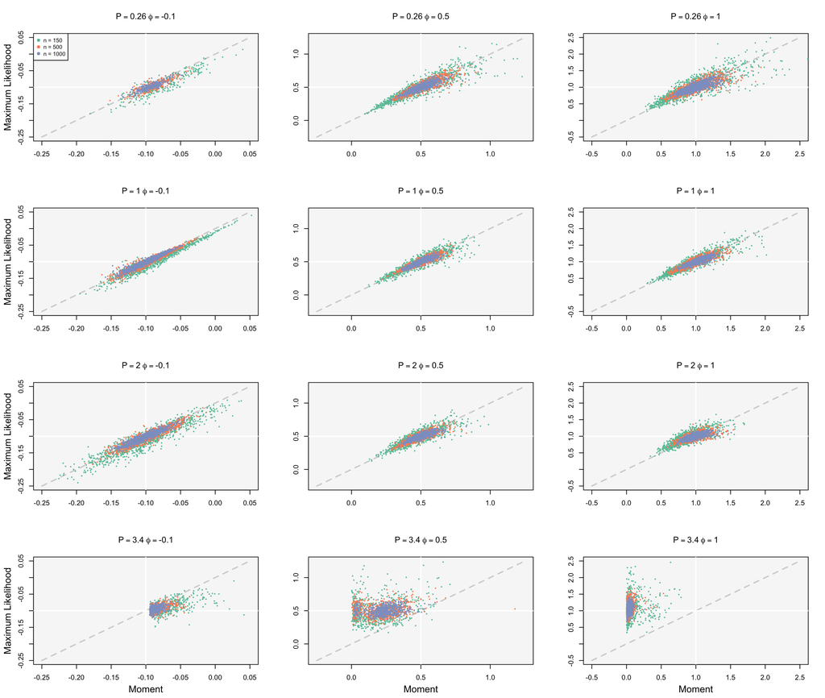

## COMPUTATION TIME

Boxplots of the 1000 log computation times (y-axis) for the thirteen fitted models (x-axis) and three sample sizes (denoted by color) when data were generated from the GP-P model for various values of $P$ and $\varphi$. Model-fitting approaches that fit the ``true" data-generating model have a darker background. The boxplots of the computation time from the proposed maximum likelihood approach are slightly darkened.

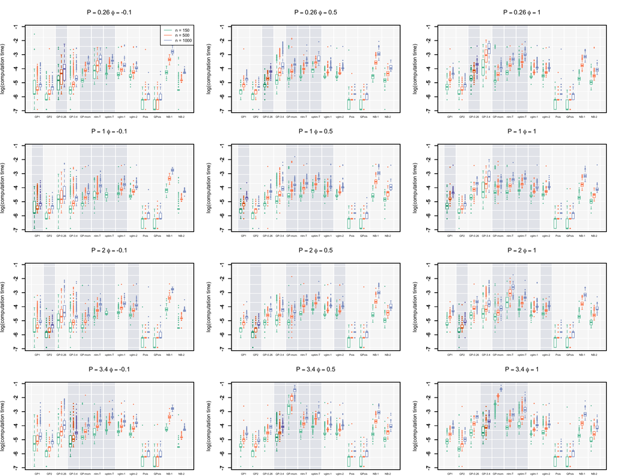

## NON-CONVERGENCE

The table below shows the proportion of times an algorithm did not converge for different data sets generated from the GP-P model for various values of $P$, $\varphi$, and sample sizes, $n$. Algorithms for GP-P when $\varphi$ estimated via method of moments, maximization of the log-likelihood via “nlm” and “optim,” and the NB-1 model sometimes did not converge. All other algorithms/models were always able to fit the data.

| P | phi | nsize | GP1 | GP2 | GP-0.26 | GP-3.4 | GP-mom | nlm-T | optim-T | vglm-1 | vglm-2 | Pois | QPois | NB-1 | NB-2 |
| --- | --- | --- | --- | --- | --- | --- | --- | --- | --- | --- | --- | --- | --- | --- | --- |
| 0.26 | -0.1 | 150 | 0 | 0 | 0 | 0 | 0.722 | 0.068 | 0.000 | 0 | 0 | 0 | 0 | 0.944 | 0 |
| 0.26 | -0.1 | 500 | 0 | 0 | 0 | 0 | 0.723 | 0.074 | 0.000 | 0 | 0 | 0 | 0 | 0.947 | 0 |
| 0.26 | -0.1 | 1000 | 0 | 0 | 0 | 0 | 0.711 | 0.077 | 0.000 | 0 | 0 | 0 | 0 | 0.941 | 0 |
| 0.26 | 0.5 | 150 | 0 | 0 | 0 | 0 | 0.000 | 0.000 | 0.010 | 0 | 0 | 0 | 0 | 0.000 | 0 |
| 0.26 | 0.5 | 500 | 0 | 0 | 0 | 0 | 0.000 | 0.000 | 0.000 | 0 | 0 | 0 | 0 | 0.000 | 0 |
| 0.26 | 0.5 | 1000 | 0 | 0 | 0 | 0 | 0.000 | 0.000 | 0.006 | 0 | 0 | 0 | 0 | 0.000 | 0 |
| 0.26 | 1 | 150 | 0 | 0 | 0 | 0 | 0.000 | 0.000 | 0.010 | 0 | 0 | 0 | 0 | 0.000 | 0 |
| 0.26 | 1 | 500 | 0 | 0 | 0 | 0 | 0.000 | 0.000 | 0.004 | 0 | 0 | 0 | 0 | 0.000 | 0 |
| 0.26 | 1 | 1000 | 0 | 0 | 0 | 0 | 0.000 | 0.000 | 0.052 | 0 | 0 | 0 | 0 | 0.000 | 0 |
| 1 | -0.1 | 150 | 0 | 0 | 0 | 0 | 0.217 | 0.038 | 0.984 | 0 | 0 | 0 | 0 | 0.950 | 0 |
| 1 | -0.1 | 500 | 0 | 0 | 0 | 0 | 0.054 | 0.010 | 1.000 | 0 | 0 | 0 | 0 | 0.939 | 0 |
| 1 | -0.1 | 1000 | 0 | 0 | 0 | 0 | 0.004 | 0.003 | 1.000 | 0 | 0 | 0 | 0 | 0.951 | 0 |
| 1 | 0.5 | 150 | 0 | 0 | 0 | 0 | 0.000 | 0.000 | 0.073 | 0 | 0 | 0 | 0 | 0.000 | 0 |
| 1 | 0.5 | 500 | 0 | 0 | 0 | 0 | 0.000 | 0.000 | 0.017 | 0 | 0 | 0 | 0 | 0.000 | 0 |
| 1 | 0.5 | 1000 | 0 | 0 | 0 | 0 | 0.000 | 0.000 | 0.003 | 0 | 0 | 0 | 0 | 0.000 | 0 |
| 1 | 1 | 150 | 0 | 0 | 0 | 0 | 0.000 | 0.000 | 0.001 | 0 | 0 | 0 | 0 | 0.000 | 0 |
| 1 | 1 | 500 | 0 | 0 | 0 | 0 | 0.000 | 0.000 | 0.000 | 0 | 0 | 0 | 0 | 0.000 | 0 |
| 1 | 1 | 1000 | 0 | 0 | 0 | 0 | 0.000 | 0.000 | 0.000 | 0 | 0 | 0 | 0 | 0.000 | 0 |
| 2 | -0.1 | 150 | 0 | 0 | 0 | 0 | 0.000 | 0.000 | 0.997 | 0 | 0 | 0 | 0 | 0.945 | 0 |
| 2 | -0.1 | 500 | 0 | 0 | 0 | 0 | 0.000 | 0.000 | 1.000 | 0 | 0 | 0 | 0 | 0.948 | 0 |
| 2 | -0.1 | 1000 | 0 | 0 | 0 | 0 | 0.000 | 0.000 | 1.000 | 0 | 0 | 0 | 0 | 0.960 | 0 |
| 2 | 0.5 | 150 | 0 | 0 | 0 | 0 | 0.000 | 0.000 | 0.087 | 0 | 0 | 0 | 0 | 0.000 | 0 |
| 2 | 0.5 | 500 | 0 | 0 | 0 | 0 | 0.000 | 0.000 | 0.032 | 0 | 0 | 0 | 0 | 0.000 | 0 |
| 2 | 0.5 | 1000 | 0 | 0 | 0 | 0 | 0.000 | 0.000 | 0.003 | 0 | 0 | 0 | 0 | 0.000 | 0 |
| 2 | 1 | 150 | 0 | 0 | 0 | 0 | 0.000 | 0.000 | 0.002 | 0 | 0 | 0 | 0 | 0.000 | 0 |
| 2 | 1 | 500 | 0 | 0 | 0 | 0 | 0.000 | 0.000 | 0.000 | 0 | 0 | 0 | 0 | 0.000 | 0 |
| 2 | 1 | 1000 | 0 | 0 | 0 | 0 | 0.000 | 0.000 | 0.000 | 0 | 0 | 0 | 0 | 0.000 | 0 |
| 3.4 | -0.1 | 150 | 0 | 0 | 0 | 0 | 0.620 | 0.132 | 0.010 | 0 | 0 | 0 | 0 | 0.945 | 0 |
| 3.4 | -0.1 | 500 | 0 | 0 | 0 | 0 | 0.629 | 0.038 | 0.001 | 0 | 0 | 0 | 0 | 0.948 | 0 |
| 3.4 | -0.1 | 1000 | 0 | 0 | 0 | 0 | 0.630 | 0.015 | 0.000 | 0 | 0 | 0 | 0 | 0.960 | 0 |
| 3.4 | 0.5 | 150 | 0 | 0 | 0 | 0 | 0.356 | 0.001 | 0.013 | 0 | 0 | 0 | 0 | 0.000 | 0 |
| 3.4 | 0.5 | 500 | 0 | 0 | 0 | 0 | 0.393 | 0.000 | 0.010 | 0 | 0 | 0 | 0 | 0.000 | 0 |
| 3.4 | 0.5 | 1000 | 0 | 0 | 0 | 0 | 0.433 | 0.000 | 0.031 | 0 | 0 | 0 | 0 | 0.000 | 0 |
| 3.4 | 1 | 150 | 0 | 0 | 0 | 0 | 0.400 | 0.000 | 0.025 | 0 | 0 | 0 | 0 | 0.000 | 0 |
| 3.4 | 1 | 500 | 0 | 0 | 0 | 0 | 0.363 | 0.000 | 0.031 | 0 | 0 | 0 | 0 | 0.000 | 0 |
| 3.4 | 1 | 1000 | 0 | 0 | 0 | 0 | 0.381 | 0.000 | 0.110 | 0 | 0 | 0 | 0 | 0.000 | 0 |